# NymPy

```python
import numpy as np
```

```python
# simple List
a = [1,2,3]
```

```python
type(a)
```

```
list
```

# Creating NymPy array

```python
b = np.array(a)
```

```python
b
```

```
array([1, 2, 3])
```

```python
type(b)
```

```
numpy.ndarray
```

```python
# Range method
```

```python
list(range(0,10))   # End value will be excluded
```

```
[0, 1, 2, 3, 4, 5, 6, 7, 8, 9]
```

```python
np.array(range(0,10))   # np array
```

```
array([0, 1, 2, 3, 4, 5, 6, 7, 8, 9])
```

```python
np.arange(0,10)    # np array using arange method
```

```
array([0, 1, 2, 3, 4, 5, 6, 7, 8, 9])
```

```python
np.linspace(0,5,6)  # np array using linspace-  End value will be included and shows in float.
```

```
array([0., 1., 2., 3., 4., 5.])
```

```python
np.linspace(0,3,31)
```

```
array([0. , 0.1, 0.2, 0.3, 0.4, 0.5, 0.6, 0.7, 0.8, 0.9, 1. , 1.1, 1.2,
       1.3, 1.4, 1.5, 1.6, 1.7, 1.8, 1.9, 2. , 2.1, 2.2, 2.3, 2.4, 2.5,
       2.6, 2.7, 2.8, 2.9, 3. ])
```

```python
#List of lists
```

```python
c = [[1,2,3],[10,20,30]]
c
```

```
[[1, 2, 3], [10, 20, 30]]
```

```python
type(c)
```

```
list
```

```python
np.array(c)   # 2-Dimensional array - Rows an Columns  -  no of items should be same.
```

```
array([[ 1,  2,  3],
       [10, 20, 30]])
```

```python
# Matrix of zeros
```

```python
np.zeros((3,4))
```

```
array([[0., 0., 0., 0.],
       [0., 0., 0., 0.],
       [0., 0., 0., 0.]])
```

```python
np.ones((3,4))
```

```
array([[1., 1., 1., 1.],
       [1., 1., 1., 1.],
       [1., 1., 1., 1.]])
```

```python
# how to create 2-D matrix with 3 rows and 10 columns
```

```python
first_thirty = np.linspace(0,29,30)
first_thirty
```

```
array([ 0.,  1.,  2.,  3.,  4.,  5.,  6.,  7.,  8.,  9., 10., 11., 12.,
       13., 14., 15., 16., 17., 18., 19., 20., 21., 22., 23., 24., 25.,
       26., 27., 28., 29.])
```

```python
first_thirty.shape
```

```
(30,)
```

```python
first_thirty.reshape(3,10)
```

```
array([[ 0.,  1.,  2.,  3.,  4.,  5.,  6.,  7.,  8.,  9.],
       [10., 11., 12., 13., 14., 15., 16., 17., 18., 19.],
       [20., 21., 22., 23., 24., 25., 26., 27., 28., 29.]])
```

```python
x_ax = np.linspace(-3,3,61)
x_ax
```

```
array([-3. , -2.9, -2.8, -2.7, -2.6, -2.5, -2.4, -2.3, -2.2, -2.1, -2. ,
       -1.9, -1.8, -1.7, -1.6, -1.5, -1.4, -1.3, -1.2, -1.1, -1. , -0.9,
       -0.8, -0.7, -0.6, -0.5, -0.4, -0.3, -0.2, -0.1,  0. ,  0.1,  0.2,
        0.3,  0.4,  0.5,  0.6,  0.7,  0.8,  0.9,  1. ,  1.1,  1.2,  1.3,
        1.4,  1.5,  1.6,  1.7,  1.8,  1.9,  2. ,  2.1,  2.2,  2.3,  2.4,
        2.5,  2.6,  2.7,  2.8,  2.9,  3. ])
```

# How to select values from an array:

```python
first_ten = np.arange(0,10)
first_ten
```

```
array([0, 1, 2, 3, 4, 5, 6, 7, 8, 9])
```

```python
first_ten[3]
```

```
3
```

```python
first_ten[3:5]
```

```
array([3, 4])
```

```python
first_ten[:2]
```

```
array([0, 1])
```

```python
first_ten[6:]
```

```
array([6, 7, 8, 9])
```

```python
first_thirty
```

```
array([ 0.,  1.,  2.,  3.,  4.,  5.,  6.,  7.,  8.,  9., 10., 11., 12.,
       13., 14., 15., 16., 17., 18., 19., 20., 21., 22., 23., 24., 25.,
       26., 27., 28., 29.])
```

```python
thirty_by_ten = first_thirty.reshape(3,10)
thirty_by_ten
```

```
array([[ 0.,  1.,  2.,  3.,  4.,  5.,  6.,  7.,  8.,  9.],
       [10., 11., 12., 13., 14., 15., 16., 17., 18., 19.],
       [20., 21., 22., 23., 24., 25., 26., 27., 28., 29.]])
```

```python
thirty_by_ten[1]
```

```
array([10., 11., 12., 13., 14., 15., 16., 17., 18., 19.])
```

```python
thirty_by_ten[1,5]
```

```
15.0
```

```python
thirty_by_ten[0:3,1:3]
```

```
array([[ 1.,  2.],
       [11., 12.],
       [21., 22.]])
```

```python
ten = np.arange(0, 10)
ten
```

```
array([0, 1, 2, 3, 4, 5, 6, 7, 8, 9])
```

```python
tens = np.arange(0, 101,10)
tens
```

```
array([  0,  10,  20,  30,  40,  50,  60,  70,  80,  90, 100])
```

```python
tens >= 60
```

```
array([False, False, False, False, False, False,  True,  True,  True,
        True,  True])
```

```python
tens[tens >= 60]   # Displaying data based on condition - Mostly used logic
```

```
array([ 60,  70,  80,  90, 100])
```

```python
#Excercise 1
my_array = np.arange(0,10)
my_array
```

```
array([0, 1, 2, 3, 4, 5, 6, 7, 8, 9])
```

```python
Filtered_array = my_array[my_array > 4]
Filtered_array
```

```
array([5, 6, 7, 8, 9])
```

```python
#Excercise 2
data = np.arange(1, 41).reshape(4, 10)
data
```

```
array([[ 1,  2,  3,  4,  5,  6,  7,  8,  9, 10],
       [11, 12, 13, 14, 15, 16, 17, 18, 19, 20],
       [21, 22, 23, 24, 25, 26, 27, 28, 29, 30],
       [31, 32, 33, 34, 35, 36, 37, 38, 39, 40]])
```

```python
my_slice = data[1:3, 3:7]
my_slice
```

```
array([[14, 15, 16, 17],
       [24, 25, 26, 27]])
```

# NymPy Part -3

```python
first_ten = np.arange(0,10)
first_ten
```

```
array([0, 1, 2, 3, 4, 5, 6, 7, 8, 9])
```

```python
first_ten + 10
```

```
array([10, 11, 12, 13, 14, 15, 16, 17, 18, 19])
```

```python
first_ten - 10
```

```
array([-10,  -9,  -8,  -7,  -6,  -5,  -4,  -3,  -2,  -1])
```

```python
first_ten + first_ten
```

```
array([ 0,  2,  4,  6,  8, 10, 12, 14, 16, 18])
```

```python
b = [1,2,3]
b
```

```
[1, 2, 3]
```

```python
b + 10        # adding values work in arrays , but not in lists
```

```
---------------------------------------------------------------------------
TypeError                                 Traceback (most recent call last)
Cell In[83], line 1
----> 1 b + 10

TypeError: can only concatenate list (not "int") to list
```

```python
first_ten
```

```
array([0, 1, 2, 3, 4, 5, 6, 7, 8, 9])
```

```python
first_ten[0] = 10          # Replacing an item with another value
first_ten
```

```
array([10,  1,  2,  3,  4,  5,  6,  7,  8,  9])
```

```python
first_ten[:] = 10
first_ten
```

```
array([10, 10, 10, 10, 10, 10, 10, 10, 10, 10])
```

```python
first_ten = np.arange(0,10)
first_ten
```

```
array([0, 1, 2, 3, 4, 5, 6, 7, 8, 9])
```

```python
first_five = first_ten[:5]
first_five
```

```
array([0, 1, 2, 3, 4])
```

```python
first_five[:] = 0  #first_five variable data is changed
first_five
```

```
array([0, 0, 0, 0, 0])
```

```python
# Data change in first_five variable reflects in first_ten array.
#To avoid this change, a seprate first_five array is to be created.
first_ten
```

```
array([0, 0, 0, 0, 0, 5, 6, 7, 8, 9])
```

```python
#Exercise 1
```

```python
np.random.seed(0)
data = np.random.randint(0, 100, 25).reshape((5, 5))
data
```

```
array([[44, 47, 64, 67, 67],
       [ 9, 83, 21, 36, 87],
       [70, 88, 88, 12, 58],
       [65, 39, 87, 46, 88],
       [81, 37, 25, 77, 72]])
```

```python
scaled_data = data/10
scaled_data
```

```
array([[4.4, 4.7, 6.4, 6.7, 6.7],
       [0.9, 8.3, 2.1, 3.6, 8.7],
       [7. , 8.8, 8.8, 1.2, 5.8],
       [6.5, 3.9, 8.7, 4.6, 8.8],
       [8.1, 3.7, 2.5, 7.7, 7.2]])
```

# Random Numbers Using NumPy

```python
#Generating Random Numbers
```

```python
import numpy as np
```

```python
np.random.rand()   # Generates a number between 0 and 1. Every time when you run it generates a new new numner
```

```
0.046098162812970966
```

```python
# If it is more than 0.5, then we will consider this as head

# and if this is equal to and less than 0.5, we will consider this as a tail.
```

```python
np.random.seed(555)   # Give any number in seed method to show same number when you run
np.random.rand()
```

```
0.7178340874802498
```

```python
np.random.rand(5)
```

```
array([0.04785513, 0.94447198, 0.68638004, 0.58120733, 0.14267862])
```

```python
np.random.rand(5) > 0.5   # > 0.5 = True  ... <= 0.5 = False
```

```
array([ True, False,  True, False, False])
```

```python
sum(np.random.rand(5) > 0.5)   # True = 1 ... False = 0
```

```
3
```

```python
# To Multi-Dimensional Array:
```

```python
np.random.rand(2,5)
```

```
array([[0.59175338, 0.89589191, 0.58957673, 0.14163778, 0.62972526],
       [0.06939255, 0.95937044, 0.27514267, 0.61636637, 0.89086931]])
```

```python
# Random number in terms of integer
```

```python
np.random.randint(0,2)   # 0 will be included and 2 will be excluded;
```

```
1
```

```python
np.random.randint(0,2,10)   # Flip a coin; 1= Head and 0 = Tail
```

```
array([1, 1, 0, 1, 0, 1, 1, 1, 1, 1])
```

```python
np.random.randint(1,7,10)  # Rolling a die
```

```
array([1, 1, 4, 6, 4, 4, 3, 4, 4, 5])
```

```python
import matplotlib.pyplot as plt
import seaborn as sns
# sns.set_theme(style="whitegrid")
# np.random.seed(555)
a = np.random.randint(1,7,6000)
sns.countplot(x=a)
plt.show()
```

[output not shown]

# If two dice are rolled, what is the probability of getting the sum of numbers Greater than 7. (Ans: 15/36 = 0.4166)

```python
import numpy as np
die1 = np.random.randint(1, 7, 10)
die2 = np.random.randint(1, 7, 10)
```

```python
die1
```

```
array([4, 5, 4, 6, 3, 2, 2, 3, 5, 2])
```

```python
die2
```

```
array([3, 5, 1, 5, 1, 1, 3, 3, 6, 4])
```

```python
die_sum = die1+die2
die_sum
```

```
array([ 7, 10,  5, 11,  4,  3,  5,  6, 11,  6])
```

```python
die1 = np.random.randint(1, 7, 1000000)
die2 = np.random.randint(1, 7, 1000000)
die_sum = die1+die2
sum(die_sum >7)/1000000      #(Ans: 15/36 = 0.4166)
```

```
0.416953
```

```python
#Excercise: Generate five random integers between 1 and 6 (both included)
```

```python
import numpy as np
np.random.seed(555)
my_ints = np.random.randint(1,7, 5)
my_ints
```

```
array([3, 2, 2, 5, 6])
```

# Binominal Distributition using NumPy

```python
import numpy as np
```

```python
np.random.binomial(1, 0.5)      # 1 coin and probability of success 0.5
```

```
0
```

```python
np.random.binomial(2, 0.5)     # 2 coins and probability of success 0.5
```

```
2
```

```python
np.random.binomial(2, 0.5, 1000)    # 2 coins, probability of success 0.5 and No of trials is 1000
```

```
array([1, 1, 1, 1, 0, 1, 1, 1, 1, 1, 0, 1, 1, 2, 0, 0, 1, 0, 1, 1, 2, 1,
       1, 0, 0, 1, 2, 2, 2, 0, 1, 1, 0, 0, 1, 2, 2, 1, 1, 1, 0, 1, 2, 2,
       2, 1, 1, 2, 2, 0, 1, 1, 1, 1, 1, 1, 1, 0, 1, 1, 2, 1, 0, 0, 1, 1,
       2, 2, 1, 1, 1, 0, 0, 0, 1, 1, 1, 1, 1, 2, 1, 0, 0, 2, 1, 2, 2, 2,
       1, 1, 0, 1, 1, 0, 1, 0, 0, 0, 2, 0, 2, 1, 1, 2, 0, 1, 1, 2, 1, 2,
       1, 0, 1, 2, 2, 1, 2, 0, 0, 1, 0, 1, 0, 0, 0, 0, 0, 0, 0, 0, 1, 0,
       0, 1, 0, 2, 2, 1, 1, 2, 1, 2, 1, 1, 2, 2, 1, 1, 1, 0, 1, 2, 1, 0,
       1, 2, 1, 0, 2, 0, 1, 0, 0, 2, 1, 1, 0, 1, 2, 2, 1, 1, 1, 1, 1, 2,
       1, 1, 1, 0, 1, 1, 1, 0, 0, 1, 1, 2, 2, 2, 1, 0, 2, 0, 1, 0, 1, 2,
       1, 2, 0, 0, 1, 0, 2, 0, 1, 0, 2, 1, 1, 0, 1, 2, 1, 2, 1, 2, 2, 2,
       1, 1, 2, 0, 2, 0, 1, 2, 1, 1, 1, 1, 1, 1, 1, 2, 1, 1, 1, 0, 1, 1,
       1, 0, 1, 1, 1, 1, 1, 2, 1, 1, 1, 0, 1, 1, 1, 2, 2, 1, 0, 0, 1, 1,
       2, 1, 2, 1, 1, 1, 2, 1, 1, 0, 0, 1, 1, 1, 0, 0, 0, 0, 1, 1, 2, 1,
       1, 0, 0, 1, 2, 1, 1, 1, 1, 1, 1, 2, 2, 1, 1, 0, 1, 1, 2, 1, 1, 0,
       1, 1, 1, 1, 1, 1, 2, 2, 1, 2, 2, 1, 0, 1, 1, 1, 1, 0, 1, 1, 1, 1,
```

[output cut: 31 more lines]

```python
two_coins = np.random.binomial(2, 0.5, 1000)
```

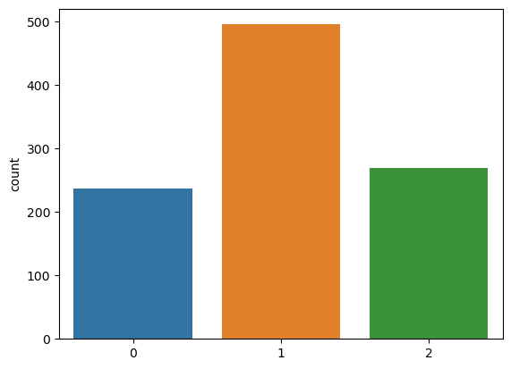

```python
import matplotlib.pyplot as plt
import seaborn as sns
sns.countplot(x = two_coins)
```

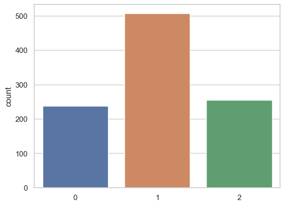

```python
sns.set_theme(style = 'whitegrid')
sns.countplot(x = two_coins)
plt.show()
```

```python
ten_coins = np.random.binomial(10, 0.5, 1000)  # 10 coins
```

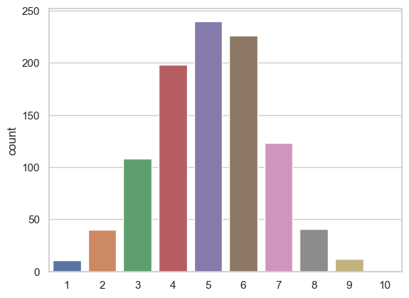

```python
sns.set_theme(style = 'whitegrid')
sns.countplot(x = ten_coins)
```

# A manufacturer has 12% defects rate in production. The buyer decides to test 20 randon pieces and will accept the supplier if there are 2 or less defectives. What is the probability of getting accepted?

```python
two_rej = np.random.binomial(20, 0.12,10)
```

```python
two_rej
```

```
array([3, 2, 2, 1, 0, 1, 3, 5, 5, 4])
```

```python
two_rej = np.random.binomial(20, 0.12,1000)
```

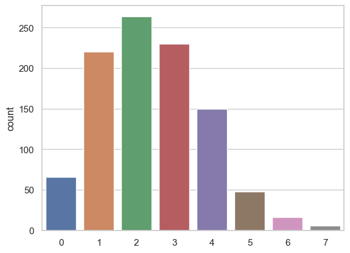

```python
sns.countplot(x = two_rej)
```

# Binominal Distributition using SciPy (SciPy > stats > binom)

```python
#import scipy.stat as st
```

```python
from scipy.stats import binom
import numpy as np
```

```python
# Cumulative distribution Function
# binom.cdf(K, N, P)
# K: is the number of defectives or less, which is =2
# N is that how many number of pieces you are selecting = 20
# P: Probability is 0.12 or 12 percent
binom.cdf(2, 20, 0.12)
```

```
0.5631315224061946
```

```python
# PMF: Probability Mass Function
binom.pmf(2, 20, 0.12)
```

```
0.27403383702748796
```

```python
binom.pmf(1, 20, 0.12)
```

```
0.211534891740517
```

```python
binom.pmf(0, 20, 0.12)
```

```
0.07756279363818959
```

```python
# Mean, Variable, Standard Deviation
binom.mean(20, 0.12)
```

```
2.4
```

```python
binom.var(20, 0.12)
```

```
2.112
```

```python
binom.std(20, 0.12)
```

```
1.453272169966796
```

```python
# The probability of getting more than two defectives.So far,what you calculated here was two or less.
1-binom.cdf(2, 20, 0.12)
```

```
0.4368684775938054
```

```python
# SF: Survival Function  =   1- cdf
binom.sf(2, 20, 0.12)
```

```
0.4368684775938054
```

```python
# binom.cdf(k,n,p) - Cumulative distribution function - for less than or equal to 2
# binom.pmf(k,n,p) - Probability mass function - for exact two defects
# binom.sf(k,n,p) - for more than 2 (similar to 1-cdf)
# binom.mean(n,p) - for mean of the distribution
# binom.var(n,p) - for variance of the distribution
# binom.std(n,p) - for standard deviation of the distribution
```

```python
x_ax = np.arange(0,21)
```

```python
x_ax
```

```
array([ 0,  1,  2,  3,  4,  5,  6,  7,  8,  9, 10, 11, 12, 13, 14, 15, 16,
       17, 18, 19, 20])
```

```python
binom.pmf(0, 20, 0.12)
```

```
0.07756279363818959
```

```python
binom.pmf(20, 20, 0.12)
```

```
3.8337599924474723e-19
```

```python
y_ax = binom.pmf(x_ax, 20, 0.12)
```

```python
import matplotlib.pyplot as plt
import seaborn as sns
```

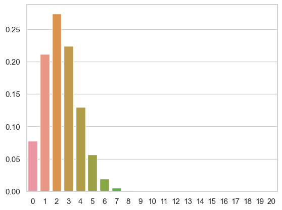

```python
# sns.set_theme(style = 'whitegrid')
sns.barplot(x= x_ax, y=y_ax)
```

```python
y_ax = binom.cdf(x_ax, 20, 0.12)
```

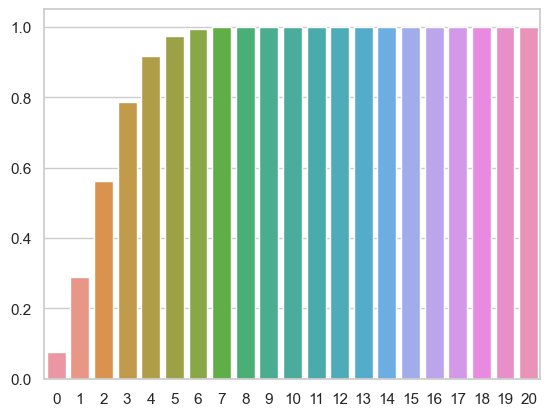

```python
sns.set_theme(style = 'whitegrid')
sns.barplot(x= x_ax, y=y_ax)
```

# In flipping a fair coin 10 times, what is the probability of getting exactly 7 heads? Assign the answer to the variable p_7heads.

```python
from scipy.stats import binom
import numpy as np
# binom.pmf(K, N, P)
# K: is the number of Head =7
# N is that how many number of times = 10
# P: Probability of a single coin is 1/2 = 0.5
binom.pmf(7, 10, 0.5)
```

```
0.11718749999999999
```

# In flipping 10 fair coins, what is the probability of getting 7 or more heads? Assign the answer to the variable p_7_or_more.

```python
1-binom.cdf(6, 10, 0.5)
```

```
0.171875
```

```python
binom.sf(6, 10, 0.5)
```

```
0.171875
```

# 4 random pieces are selected from a lot with 10% defective. What is the probability that there are 0 defective pieces in this selection? Assign the answer to the variable p_0_defects.

```python
# binom.pmf(K, N, P)
# K: is the number of defectives or less, which is =0
# N is that how many number of pieces you are selecting = 4
# P: Probability is 0.1 or 10 percent
binom.cdf(0, 4, 0.1)
```

```
0.6561
```

```python
binom.pmf(0, 4, 0.1)
```

```
0.6561
```

# Poisson Distribution using NumPy

```python
import numpy as np
import matplotlib as plt
import seaborn as sns
```

```python
np.random.poisson(3.6)
```

```
4
```

```python
np.random.poisson(3.6,10)
```

```
array([1, 7, 2, 3, 2, 4, 3, 2, 7, 3])
```

```python
q_size = np.random.poisson(3.6,1000)
```

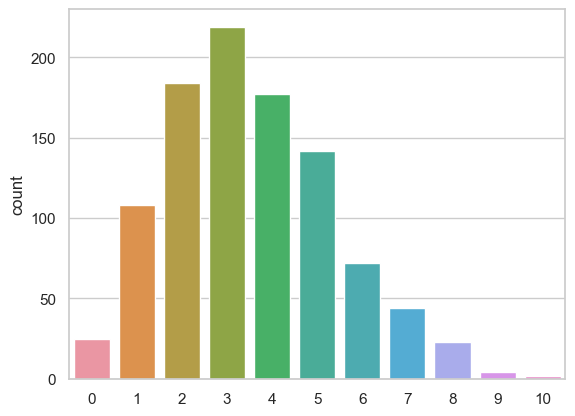

```python
sns.countplot(x = q_size)
```

# Poisson Distribution using SciPy

```python
import numpy as np
import matplotlib as plt
import seaborn as sns
from scipy.stats import poisson
```

```python
poisson.pmf(7,3.6)
```

```
0.04248414026930935
```

```python
poisson.cdf(7,3.6)
```

```
0.9692107246403425
```

```python
# poisson.cdf(k,mu) - Cumulative distribution function - for less than or equal to
# poisson.pmf(k,mu) - Probability mass function - for exact value
# poisson.sf(k,mu) - for more than (similar to 1-cdf)
# poisson.mean(mu) - for mean of the distribution
# poisson.var(mu) - for variance of the distribution
# poisson.std(mu) - for standard deviation of the distribution
```

```python
# cdf + sf =1
# cdf = upto 7 (Cumulative)
# sf = after 7 (Cumulative)
# so, sf = 1 - cdf
poisson.sf(7,3.6)
```

```
0.030789275359657444
```

```python
1-poisson.cdf(7,3.6)
```

```
0.030789275359657475
```

```python
poisson.mean(3.6)
```

```
3.6
```

```python
poisson.var(3.6)
```

```
3.6
```

```python
poisson.std(3.6)
```

```
1.8973665961010275
```

```python
x_ax = np.arange(0,11)
x_ax
```

```
array([ 0,  1,  2,  3,  4,  5,  6,  7,  8,  9, 10])
```

```python
y_ax = poisson.pmf(x_ax,3.6)
y_ax
```

```
array([0.02732372, 0.0983654 , 0.17705772, 0.21246927, 0.19122234,
       0.13768008, 0.08260805, 0.04248414, 0.01911786, 0.00764715,
       0.00275297])
```

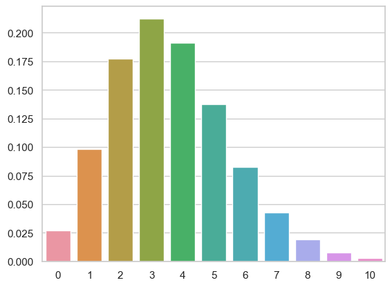

```python
sns.barplot(x = x_ax, y = y_ax)
```

```python
y_ax = poisson.cdf(x_ax,3.6)
y_ax
```

```
array([0.02732372, 0.12568912, 0.30274684, 0.51521611, 0.70643845,
       0.84411853, 0.92672658, 0.96921072, 0.98832859, 0.99597573,
       0.99872871])
```

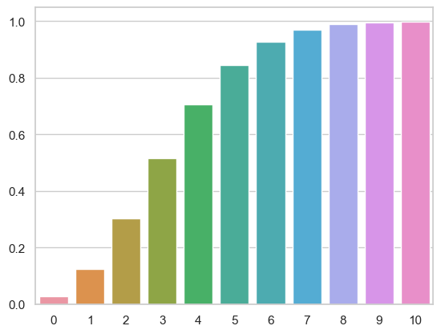

```python
sns.barplot(x = x_ax, y = y_ax)
```

# A company receives on average 4.6 calls per hour. What is the probability of getting exactly 8 calls in an hour? Assume that the call volume follows the Poisson Distribution. Assign the answer to the variable p8 .

```python
p8 = poisson.pmf(8, 4.6)
p8
```

```
0.049978994352065334
```

# A company receives on average 4.6 calls per hour. What is the probability of getting more than 6 calls in an hour? Consider the call volume follows the Poisson Distribution. Assign the answer to the variable p_gt_6

```python
p_gt_6 = poisson.sf(6,4.6)
p_gt_6
```

```
0.1819709485818438
```

```python
poisson.cdf(6,4.6)
```

```
0.8180290514181562
```

# Normal Distribution using NumPy

```python
import numpy as np
import matplotlib.pyplot as plt
import seaborn as sns
```

```python
np.random.normal(100,2)    # size = 100 mm Rods; S.D. = 2)
```

```
101.83967484888484
```

```python
np.random.normal(100,2,10)    # size = 100 mm Rods; S.D. = 2. Samples= 10)
```

```
array([102.44268142, 102.43223425, 102.55293442, 102.30617994,
        98.60144318,  99.90018692, 101.50969983, 100.40244498,
       100.78180786,  99.92268668])
```

```python
np.round(np.random.normal(100,2,10), 2) # using Rndom, we get some samples.
```

```
array([ 97.23,  98.49,  98.68,  99.87, 104.17,  99.02,  96.6 , 100.41,
       102.81, 102.05])
```

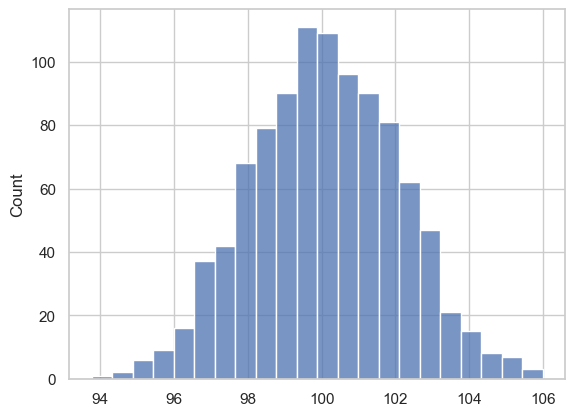

```python
a = np.random.normal(100,2,1000)
sns.histplot(x=a)
plt.show()
```

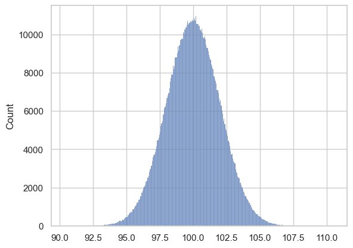

```python
a = np.random.normal(100,2,1000000)
sns.histplot(x=a)
plt.show()
```

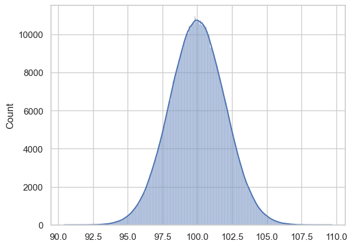

```python
a = np.random.normal(100,2,1000000)
sns.histplot(x=a, kde = True)      # kde -Kernel Density Estimate, it makes the curve smooth
```

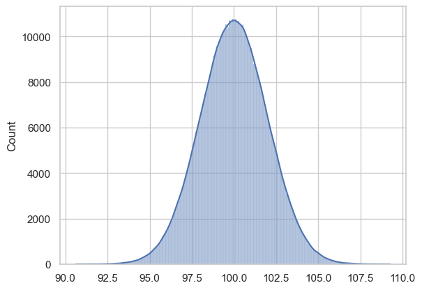

```python
# sns.set_theme(style = "whitegrid")
a = np.random.normal(100,2,1000000)
sns.histplot(x=a, kde = True)
plt.show()
```

```python
sum( ( a > 98) & ( a < 102))    # 68%
```

```
682268
```

```python
sum( ( a > 96) & ( a < 104))    # 95%
```

```
954582
```

```python
sum( ( a > 94) & ( a < 106))    # 99.7%
```

```
997321
```